# Principles of Spatial Scale, Part 2

### Set color palette

With ColorBrewer, we can switch palettes. If you would like to change the direction of the palette, just add a “negative” sign.

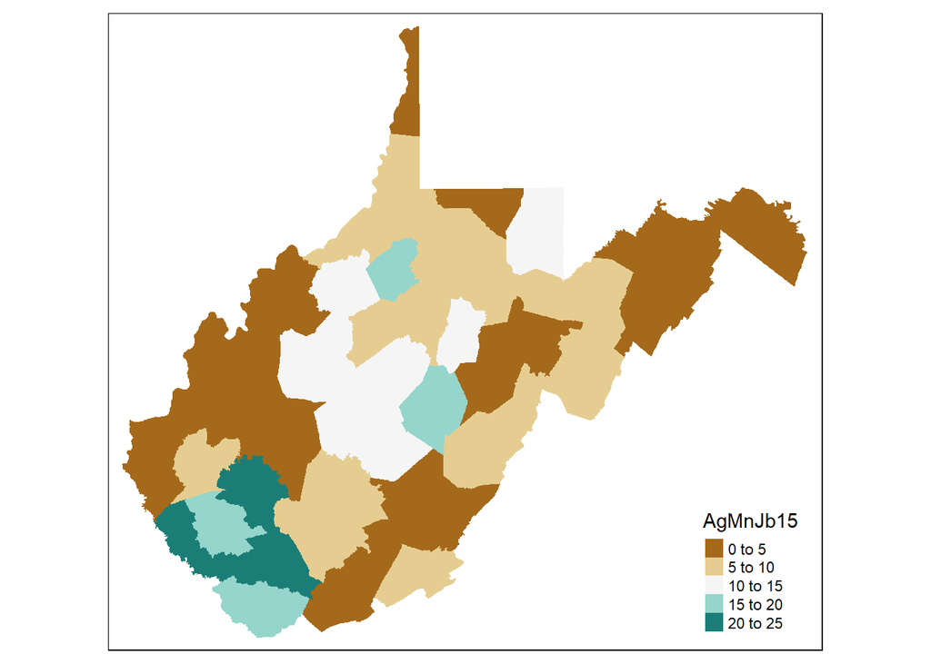

```r
# setting a color palette
tm_shape(WV_county) + tm_fill("AgMnJb15", palette = "BrBG")
```

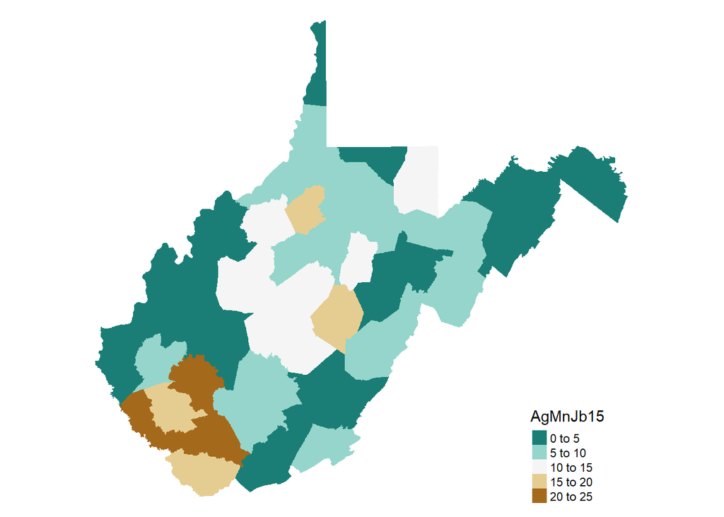

```r
# alternate: adjust legend position
tm_shape(WV_county) + tm_fill("AgMnJb15", palette = "-BrBG") +
  tm_layout(legend.position=c(.8,0), frame = FALSE)
```

### Classify Data

You can also change the data classification interval. It defaults on a “pretty classification” which has been optimized for easy-to-read breaks, but may not best reflect the actual data distribution To see different parameter options, research the `tmap` documentation page.

Here we try quantile breaks, and then specific the number of levels or breaks.

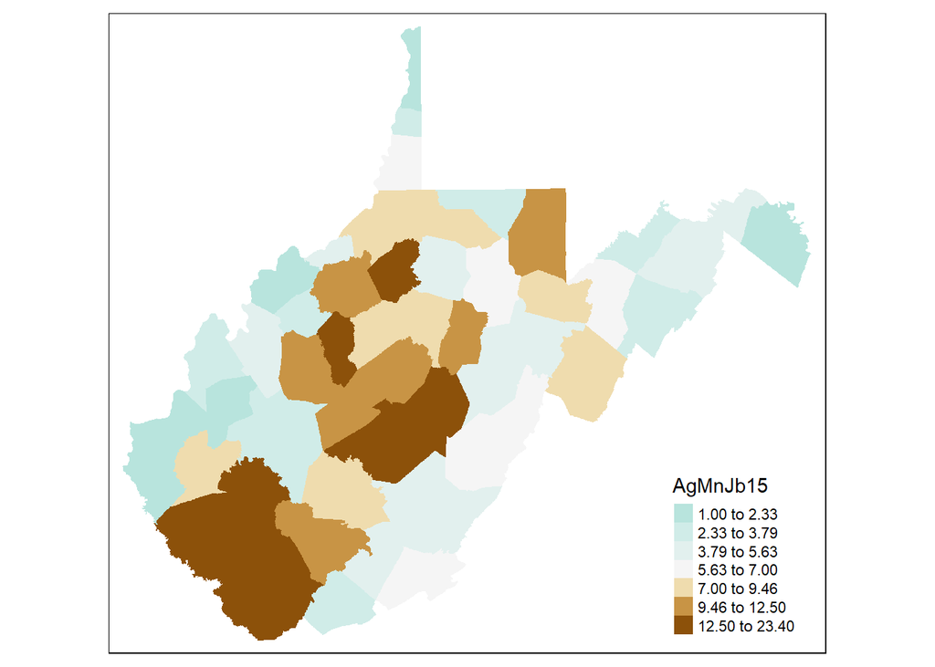

```r
# changing the intervals
quantile_map <- tm_shape(WV_county) + tm_fill("AgMnJb15", style = "quantile", palette = "-BrBG")

# number of levels
tm_shape(WV_county) + tm_fill("AgMnJb15", style = "quantile", n = 7, palette = "-BrBG")
```

How does this change your interpretation? Try additional parameter specifications like “jenks” for jenks breaks, or “sd” for standard deviation breaks.

### Customize Maps

There are multiple other options when designing maps using `tmap.` Many of these are best optimized for generating in an R script directly, rather than in an RMarkdown, as RStudio can enforce odd behaviors when it doesn’t have full space to generate plots. Take the following code as examples for what you should try in your own RStudio environment within an R script (rather than an RMarkdown file).

Finally, experiment with the parameters here, and continue to explore the tmap documentation. (Google search terms: “tmap R” to get information directly.)

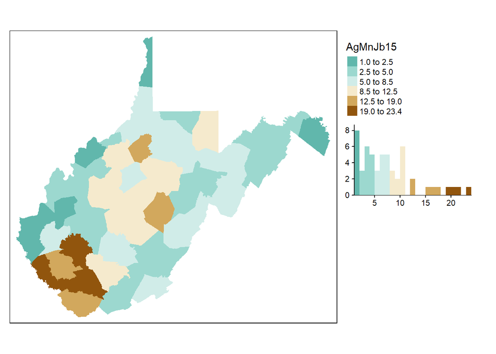

```r
# includes a histogram in the legend
tm_shape(WV_county) + tm_fill("AgMnJb15", style = "jenks", n = 6, palette = "-BrBG", legend.hist = TRUE) + tm_layout(legend.outside = TRUE, legend.hist.width = 2)
```

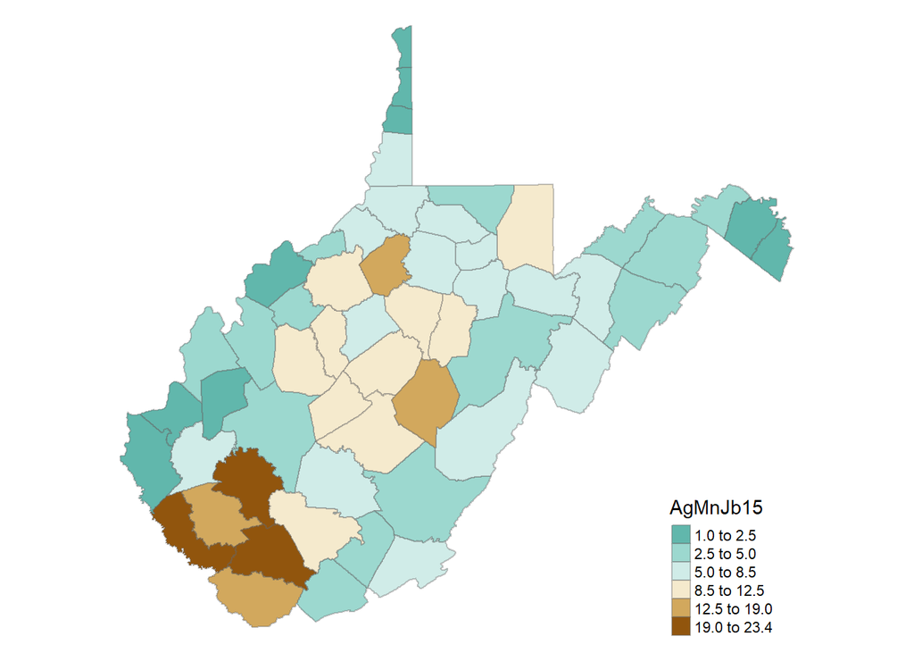

```r
# add borders
tm_shape(WV_county) +
  tm_fill("AgMnJb15", style = "jenks", n=6, palette = "-BrBG") +
  tm_borders(alpha=.4) +
  tm_layout(legend.position=c(.8,0), legend.height = 0.4, frame = FALSE)
```

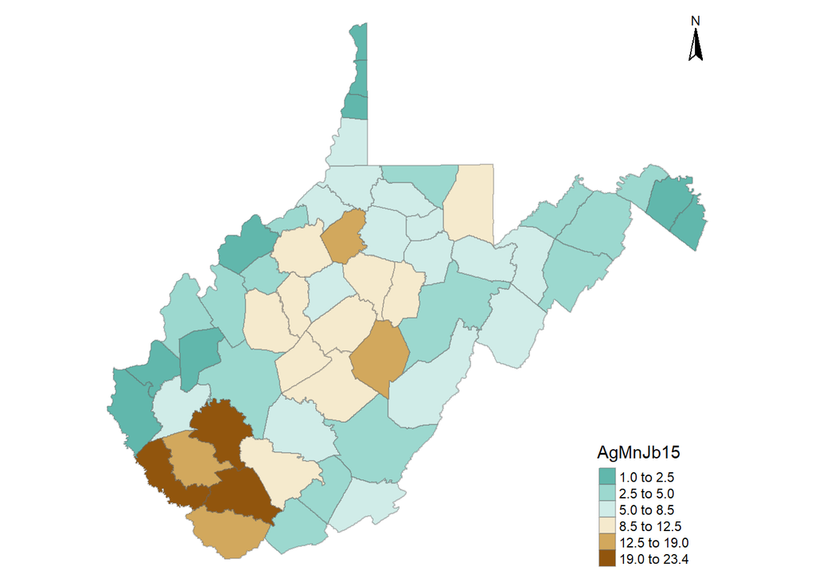

```r
# north arrow
tm_shape(WV_county) + tm_fill("AgMnJb15", style = "jenks", n=6, palette = "-BrBG") +
  tm_borders(alpha=.4) +
  tm_compass(text.size = 0.7, position=c('RIGHT', 'TOP')) +
  tm_layout(legend.position=c(.8,0), legend.height = 0.4, frame = FALSE)
```

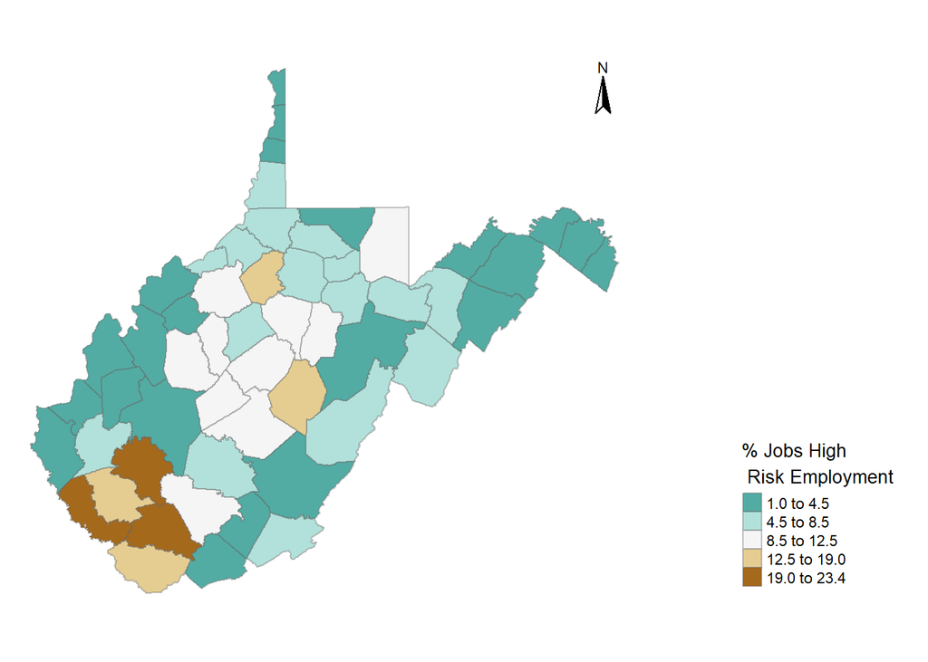

```r
# adds in legend outside the frame
tm_shape(WV_county) + tm_fill("AgMnJb15", style = "jenks", palette = "-BrBG", title = "% Jobs High \n Risk Employment") +
  tm_borders(alpha=.4) +
  tm_compass(text.size = 0.7, position=c('RIGHT', 'TOP')) +
  tm_layout(legend.title.size = 1, legend.outside = TRUE, legend.position = c('right','bottom'), frame = FALSE)
```

### Facet mapping

Now that we have a master spatial dataset that includes both mining job proxies, we can compare them. How close is the mining proxy data from the ACS profile to the actual mining employment numbers from BLS? To do this we generate a “facet map” meaning we show multiple maps, side by side.

We first assign each map to a variable, and then use either `tmap_arrange` or `tm_facets` to generate our facet maps.

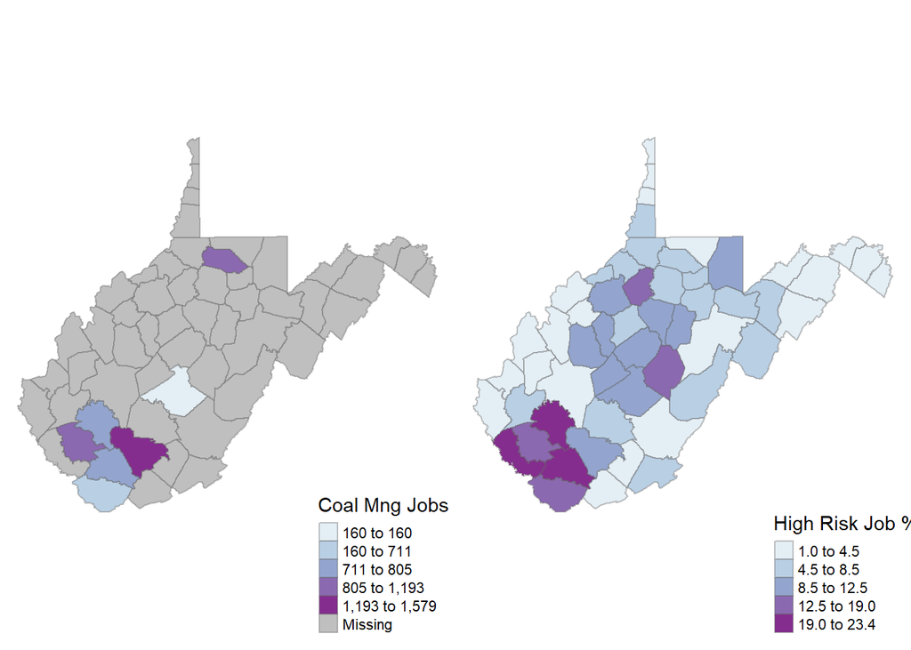

```r
# ReMap
BLSData <- tm_shape(WV_county) + tm_fill("AvEmp17", palette = "BuPu", style = "jenks", title = "Coal Mng Jobs") +
  tm_borders(alpha=.4) +
  tm_layout(legend.position = c(.7, 0), frame = FALSE)

ACSData <- tm_shape(WV_county) + tm_fill("AgMnJb15", palette = "BuPu", style = "jenks", title = "High Risk Job %") +
  tm_borders(alpha=.4) +
  tm_layout(legend.position = c(.7, 0), frame = FALSE)

tmap_arrange(BLSData,ACSData)
```

Here’s another way to generate the maps side by side:

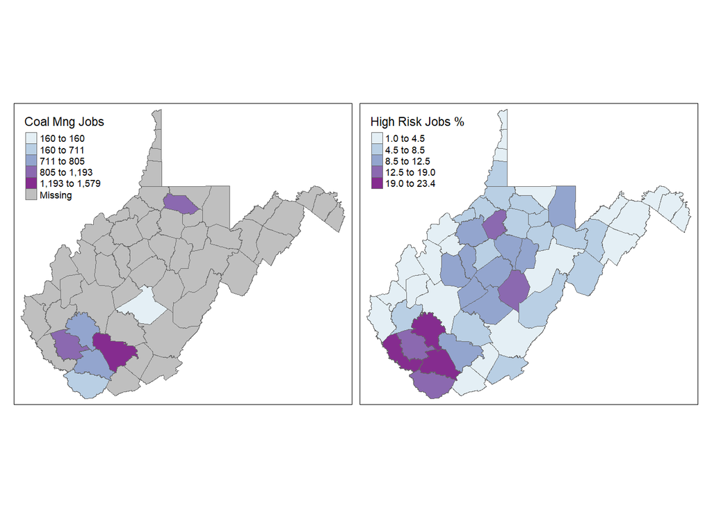

```r
# Another Route:
tm_shape(WV_county) +
  tm_polygons(c("AvEmp17", "AgMnJb15"),
              style=c("jenks", "jenks"),
              palette=list("BuPu", "BuPu"),
              title=c("Coal Mng Jobs", "High Risk Jobs %")) +
  #tm_layout(legend.position = c(0,.65), frame=FALSE) +
  tm_facets(ncol=2)
```

Obviously the ACS data is overestimating in some areas, and undestimating in others. While it captures the increase in mining jobs in the Southermost area, it misses the county with the highest mining jobs when considering all the other employment categories included. Getting finer resolution data for coal mining below county may not be available, but at least we know relatively how useful this Census category is.

# Using a Census API

In this lab I provided the raw data to you for 2015 that you wrangled and cleaned. Another excellent option in R coding environments is using a package to extract Census data for you. While you won’t be able to access all the data the same way, for some of the “classic” indicators like population demographics and income, using the Census API is the most efficient approach.

Let’s extract median income for WV counties and census tracts to see if we gain any insight into our analysis.

## Workspace Setup

Examples in this section were sourced from Kyle Walker’s guide to using tidycensus: [Basic Usage of tidycensus](https://walkerke.github.io/tidycensus/articles/basic-usage.html) and [Spatial Data in tidycensus](https://walkerke.github.io/tidycensus/articles/spatial-data.html). If you run into challenges, feel free to peruse the original context for more ideas.

### Load libraries

```r
library(tidyverse)
library(tidycensus)
options(tigris_use_cache = TRUE)
```

### Activating your API key

To work with tidycensus, you must first register for and activate your Census API key. A key can be obtained from http://api.census.gov/data/key_signup.html. Register and activate your API key.

Next, add your API key to your RStudio coding environment. This should be done in your console or your personal file; the API key should not be shared. I include dummy code below that has been commented out. For my implementation to work, I needed to add two additional parameters after simple debugging.

```r
#census_api_key("YOURAPIKEY", install=TRUE, overwrite = TRUE)
```

To check for an already installed census API key, run

```r
#Sys.getenv("CENSUS_API_KEY")
```

```r
ACS19var <- load_variables(2019, "acs5", cache = TRUE)
view(ACS19var)
```

## Extract Census data

*Note:* This call can take some time to pull. It’s not necessary to go through for the lab, so it’s okay to skip if you are running into issues.

### Access census estimates

```r
WV_county_medinc <- get_acs(geography = "county",
              variables = c(medincome = "B19013_001"),
              state = "WV",
              year = 2019)
WV_county_medinc
```

```
## # A tibble: 55 × 5
##    GEOID NAME                            variable  estimate   moe
##    <chr> <chr>                           <chr>        <dbl> <dbl>
##  1 54001 Barbour County, West Virginia   medincome    38459  4015
##  2 54003 Berkeley County, West Virginia  medincome    62515  1954
##  3 54005 Boone County, West Virginia     medincome    40739  2817
##  4 54007 Braxton County, West Virginia   medincome    41466  4728
##  5 54009 Brooke County, West Virginia    medincome    51496  4518
##  6 54011 Cabell County, West Virginia    medincome    40028  1580
##  7 54013 Calhoun County, West Virginia   medincome    38382  5756
##  8 54015 Clay County, West Virginia      medincome    35024  4796
##  9 54017 Doddridge County, West Virginia medincome    45545  5363
## 10 54019 Fayette County, West Virginia   medincome    41394  2420
## # … with 45 more rows
```

### Access merged spatial file

The latest edition of `tidycensus` adds the ability to extract census attribute data with the spatial data already merged. The object is thus a spatial file, not a simple data file.

```r
WV_county_medinc.sp <- get_acs(state = "WV",
                     geography = "county",
                     variables = "B19013_001",
                     geometry = TRUE)
head(WV_county_medinc.sp)
```

```
## Simple feature collection with 6 features and 5 fields
## Geometry type: MULTIPOLYGON
## Dimension:     XY
## Bounding box:  xmin: -82.50768 ymin: 37.94364 xmax: -80.52564 ymax: 39.45141
## Geodetic CRS:  NAD83
##   GEOID                            NAME   variable estimate  moe
## 1 54107      Wood County, West Virginia B19013_001    50231 1875
## 2 54043   Lincoln County, West Virginia B19013_001    46683 5851
## 3 54085   Ritchie County, West Virginia B19013_001    45184 4026
## 4 54021    Gilmer County, West Virginia B19013_001    45870 7264
## 5 54017 Doddridge County, West Virginia B19013_001    58750 9831
## 6 54011    Cabell County, West Virginia B19013_001    43779 2031
##                         geometry
## 1 MULTIPOLYGON (((-81.75582 3...
## 2 MULTIPOLYGON (((-82.30639 3...
## 3 MULTIPOLYGON (((-81.32879 3...
## 4 MULTIPOLYGON (((-81.05671 3...
## 5 MULTIPOLYGON (((-80.91384 3...
## 6 MULTIPOLYGON (((-82.50768 3...
```

### Plot ACS data

Using Walker’s `tidycensus` vignette, you can quickly plot the data using `ggplot`. We didn’t need to install `ggplot` because it was part of the `tidyverse` library.

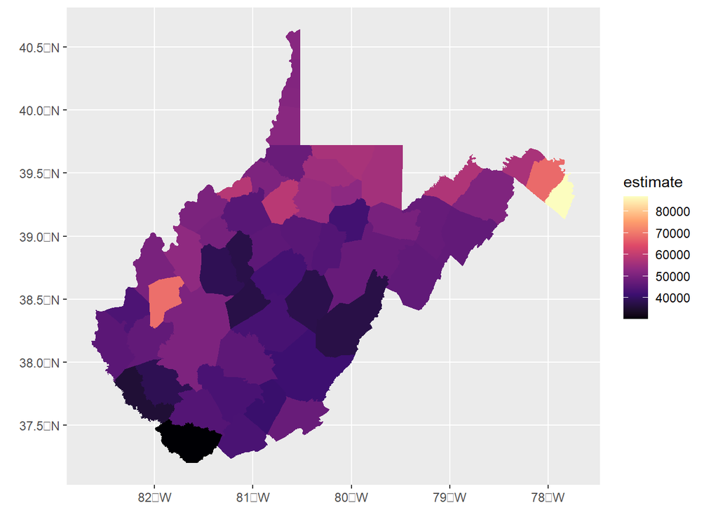

```r
WV_county_medinc.sp %>%
  ggplot(aes(fill = estimate)) +
  geom_sf(color = NA) +
  scale_fill_viridis_c(option = "magma")
```

Of course, you can also plot using `tmap.` Note that the variable of interest is called “estimate” here, using the `tidycensus` default. I recommend just working with one attribute at a time when first working with `tidycensus` and R.

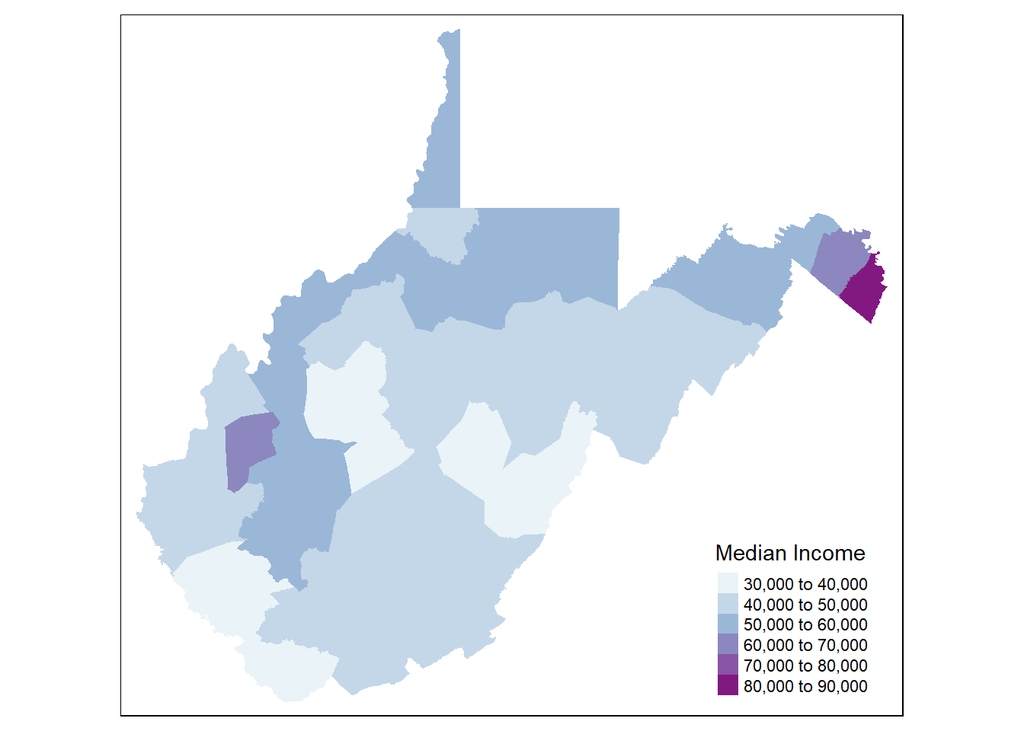

```r
tm_shape(WV_county_medinc.sp) + tm_fill("estimate", palette = "BuPu", title ="Median Income")
```

## Rinse and Repeat

What’s nice about `tidycensus` is that we can quickly run the same function to get the spatial data at a different resolution. Here we can gather median income information at the tract level.

```r
WV_tracts_medinc.sp <- get_acs(state = "WV",
                     geography = "tract",
                     variables = "B19013_001",
                     geometry = TRUE)
head(WV_tracts_medinc.sp)
```

```
## Simple feature collection with 6 features and 5 fields
## Geometry type: MULTIPOLYGON
## Dimension:     XY
## Bounding box:  xmin: -82.54137 ymin: 38.3537 xmax: -79.28936 ymax: 39.21481
## Geodetic CRS:  NAD83
##         GEOID                                            NAME   variable
## 1 54099005100    Census Tract 51, Wayne County, West Virginia B19013_001
## 2 54093965300 Census Tract 9653, Tucker County, West Virginia B19013_001
## 3 54039000800   Census Tract 8, Kanawha County, West Virginia B19013_001
## 4 54011001300   Census Tract 13, Cabell County, West Virginia B19013_001
## 5 54011001600   Census Tract 16, Cabell County, West Virginia B19013_001
## 6 54097967100 Census Tract 9671, Upshur County, West Virginia B19013_001
##   estimate  moe                       geometry
## 1    48478 9563 MULTIPOLYGON (((-82.54137 3...
## 2    51829 6184 MULTIPOLYGON (((-79.65461 3...
## 3    21660 3768 MULTIPOLYGON (((-81.65595 3...
## 4    41740 6315 MULTIPOLYGON (((-82.44872 3...
## 5    35038 7010 MULTIPOLYGON (((-82.42155 3...
## 6    46268 7336 MULTIPOLYGON (((-80.2385 38...
```

Next, we can plot it using both `ggplot` and `tmap.`

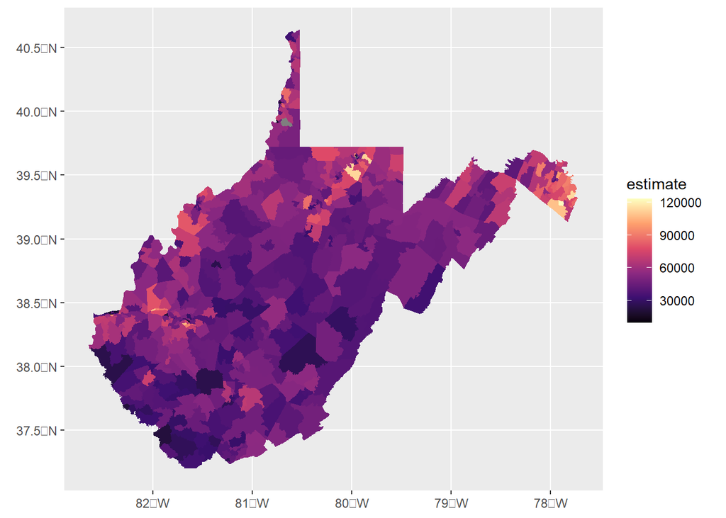

```r
WV_tracts_medinc.sp %>%
  ggplot(aes(fill = estimate)) +
  geom_sf(color = NA) +
  scale_fill_viridis_c(option = "magma")
```

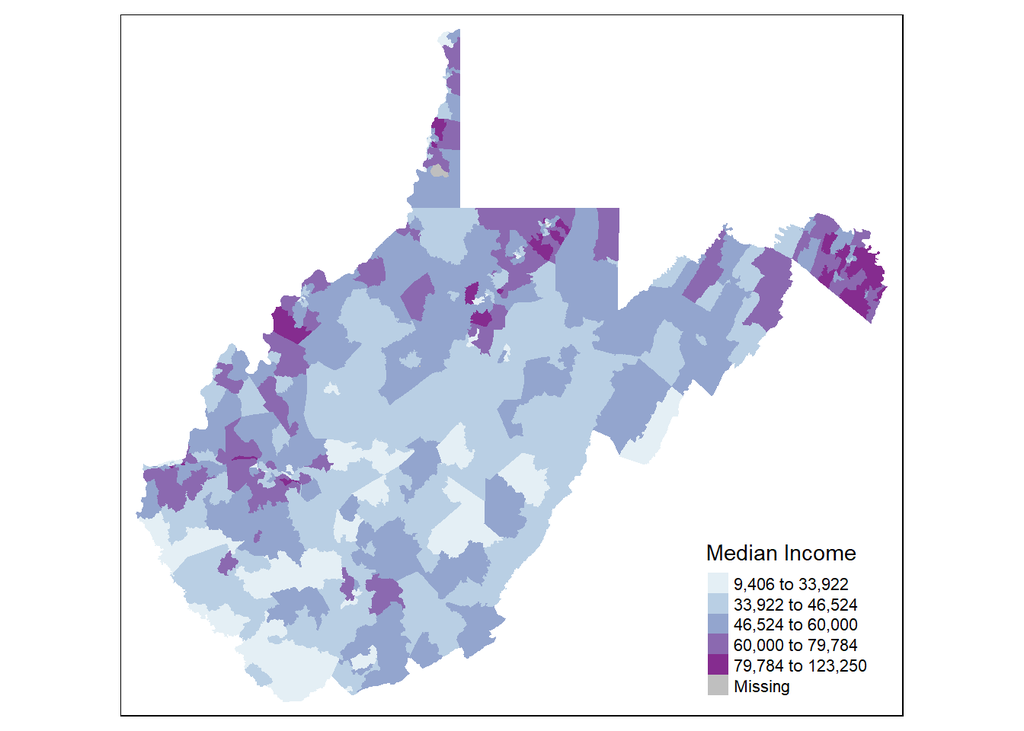

```r
tm_shape(WV_tracts_medinc.sp) +
  tm_fill("estimate", style = "jenks", palette = "BuPu", title ="Median Income")
```

What new insights did you find?

# Scale of Coal Mining

Finally – so, what about the scale of coal mining in West Virginia? While we know the ACS data is an imperfect representation of coal mining the state, we also know it captures some of the higher proportions of mining employment, especially in the Southern part of the state.

Thus, let’s map this variable at County and Tract scales to look for some patterns.

## Extact Data

First, we extract the data:

```r
WV_county_mining.sp <- get_acs(state = "WV",
                     geography = "county",
                     variables = "B24031_002",
                     geometry = TRUE)
WV_tracts_mining.sp <- get_acs(state = "WV",
                     geography = "tract",
                     variables = "B24031_002",
                     geometry = TRUE)
```

## Map Data

Next, we map both side by side:

```r
# ReMap
WVCounties <- tm_shape(WV_county_mining.sp) +
  tm_fill("estimate", n=4, palette = "BuPu", style = "jenks", title = "High Risk Jobs") +
  tm_borders(alpha=.4) +
  tm_layout(legend.text.size = .8, legend.title.size = 1.0, legend.position = c("right", "bottom"), frame = FALSE)

WVTracts <- tm_shape(WV_tracts_mining.sp) + tm_fill("estimate", n=4, palette = "BuPu", style = "jenks", title = "High Risk Jobs") +
  tm_borders(alpha=.4) +
  tm_layout(legend.text.size = .8, legend.title.size = 1.0, legend.position = c("right", "bottom"), frame = FALSE)

tmap_arrange(WVCounties,WVTracts)
```

```
## Some legend labels were too wide. These labels have been resized to 0.73, 0.68. Increase legend.width (argument of tm_layout) to make the legend wider and therefore the labels larger.
```

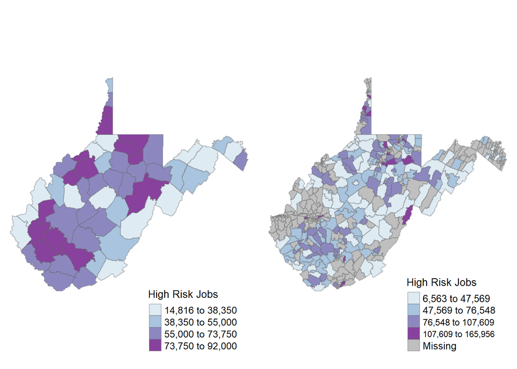

## Interpretation

What type of variation do you find between these maps? Knowing that there is more connection with mining in the Southern area, were you surprised by the variation below the county level? At what scale is coal mining employment occurring? Broadening to a wider “High Risk Employment” category for jobs that are more prone to accidents (including construction, mining, agricultural, etc) captured in this Census variable, what additional insights might you have?

Note that this variable is sometimes used for identifying areas at risk for opioid overdose. If some jobs are more prone to injury, then workers could also be more prone to getting prescription opioids for pain management, a component of the opioid epidemic. At the same time, these areas often have few other job options. When high-paying coal mining jobs go away (“high” relative to median income in the area), there may not be other options that promise the same pay and/or stability. This “economics of despair” concept likewise is thought the drive increases in opioid-related overdoses. Consider the complexity here – and how might you further detangle these concepts?

# Appendix

## Write to CSV

After all the hard work in this analysis, you’ll want to save the master files you generated. One option is to save the attribute component of the data you generated, using a `CSV` file. Uncomment and run on your own. If you leave it uncommented, every time you run the code in this lab, you will save a new CSV file (overwriting the previous version).

```r
#write.csv(WV_county, "WV_county.csv")
```

## Write to SHP

The `st_write` function saves the spatial file as a `shapefile.` For example you can save the county file you updated earlier. Uncomment and run on your own. The file is save to your working directory.

```r
#st_write(WV_county, "data/WV_county.shp")
```

## Census Data Access

While the `tidycensus` package is great for straightforward variables like income level, it may not always be for all variables. For example, if we search for “mining” in the existing View only a small selection is returned. We could for example try variable “B08126_002” corresponding to the total estimate of persons in Agriculture, forestry, fishing and hunting, and mining industries, but this is not the percentage of the workforce in these industries (which would be more precise). Rather than calculate this on our own (which also needs to account for the total able-to-work population), it’s more efficient to use pre-calculated Census metrics.

I thus recommend that for more detailed Census explorations, you take the time to get familiar with various Census data profiles. For example, the DP03 data profile of the American Community Survey with selected economic characteristics is especially useful for our purposes here.

For your own research, I recommend investigating [IPUMS](https://ipums.org/) and the newly revised [Data.gov](https://www.data.gov/) site that releases more detailed Census profiles with their required metadata components. The previous version, American Factfinder, has been retired.